# STAT 131 Final Project

Mina Lee, Isha Vaish, Tom Zhang

2023-04-20

# Part 1: Dataset Exploration

The goal of our project is to predict Korean Stock Market Volatility (VKOSPI) which is equivalent to the VIX in the United States. We will do this using the Options in Korean Stock Market Kaggle Dataset that can be found [here](https://www.kaggle.com/datasets/ninetyninenewton/vkospi).

We begin by loading in the data set…

```r
# import the data
ds <- read.csv('options_KR.csv')
head(ds)
```

```
##         Date VKOSPI KOSPI200 Open_interest For_KOSPI_Netbuying_Amount
## 1 2009-06-02  33.45   180.90       4377777               494000000000
## 2 2009-06-03  32.66   180.47       4562690               -89970739025
## 3 2009-06-04  32.56   180.31       4827524              -109000000000
## 4 2009-06-05  32.95   175.75       5022921                98420238820
## 5 2009-06-08  30.41   177.77       5293996                43291792420
## 6 2009-06-09  30.46   177.67       5520545                92510578190
##   For_Future_Netbuying_Quantity For_Call_Netbuying_Quantity
## 1                         -4953                      -24646
## 2                            47                      -57128
## 3                         -7666                       -2000
## 4                           969                       64792
## 5                          5797                       10995
## 6                        -10439                       -9091
##   For_Put_Netbuying_Quantity Indiv_Future_Netbuying_Quantity
```

[output cut: 20 more lines]

Next, let’s take a look at the KOSPI 200 and VKSOPI trace plots…

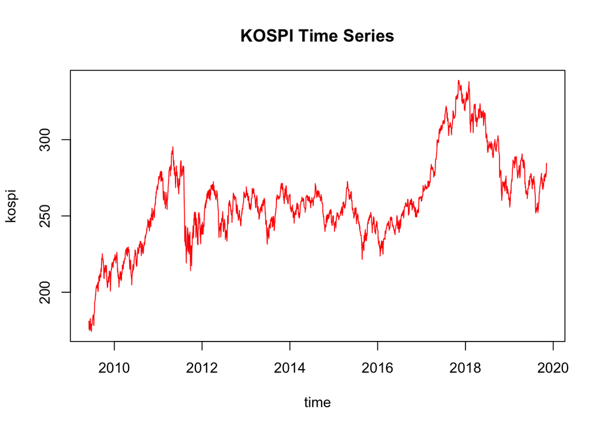

```r
time <- as.Date(ds$Date)
kospi <- ts(ds$KOSPI200) #daily returns
vkospi <- ts(ds$VKOSPI) #volatility

plot(time, kospi, type='l', col='red', main="KOSPI Time Series")
```

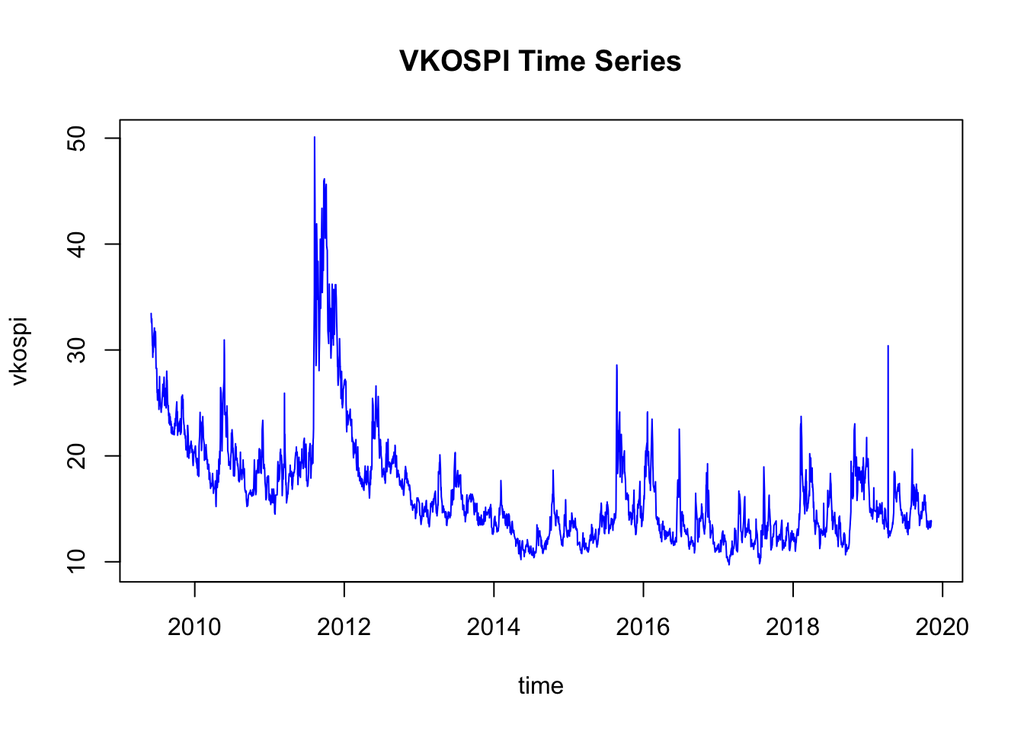

```r
plot(time, vkospi, type='l',col='blue', main = "VKOSPI Time Series")
```

From the above trace plots, we notice a trend in both the KOSPI (increasing trend) and VKOSPI (decreasing trend). Both timeseries also don’t seem to be stationary. First, let’s take the log of KOSPI and try de-trending it.

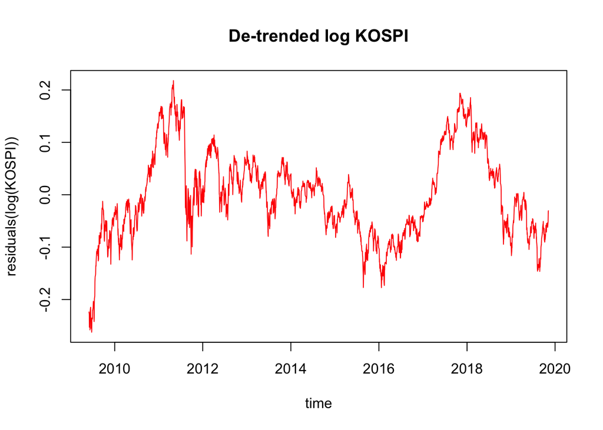

```r
# pre-processing KOSPI
log_kospi = log(kospi) #take log
detrended_kospi = residuals(lm(log_kospi ~ seq_along(log_kospi))) #de-trend
plot(time,detrended_kospi, type= 'l', col = 'Red', main = "De-trended log KOSPI", ylab = "residuals(log(KOSPI))")
```

While we seem to have removed the linearly increasing trend, there appears to be apparent seasonality. Let’s try differencing with lag 1.

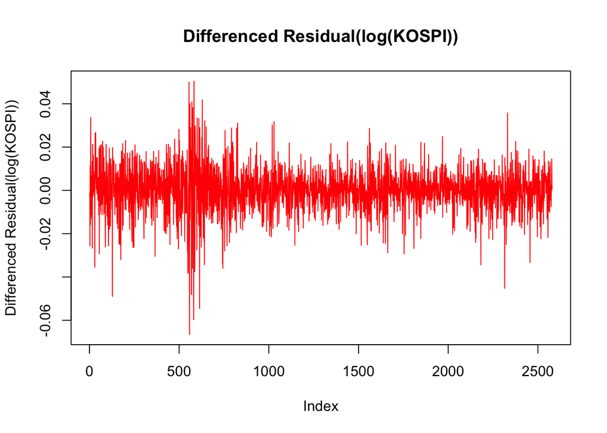

```r
plot(diff(detrended_kospi), type='l', col='red',main='Differenced Residual(log(KOSPI))', ylab = "Differenced Residual(log(KOSPI))")
```

This looks so much better! We seem to have removed the linear trend and seasonality! The series looks a lot more stationary now.

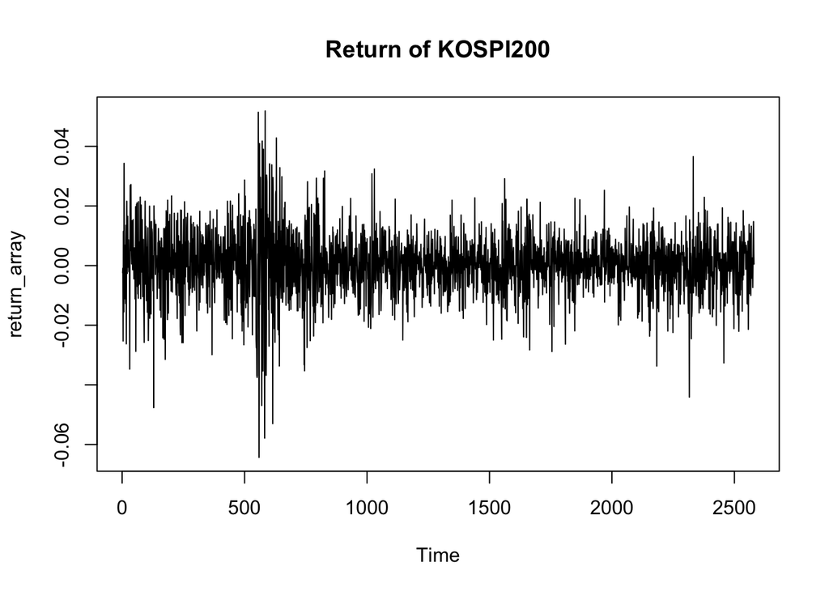

```r
# Double checking our pre-processing math and seeing if it matches the formula!
KOSPI200_yesterday <- lag(ds$KOSPI200, n = 1)
return_array = (kospi-KOSPI200_yesterday) / KOSPI200_yesterday
plot(return_array, type='l', main='Return of KOSPI200')
```

It matches! We will know refer to our differenced(residual(log(KOSPI))) series as our Return. Let’s check the mean of our returns…

```r
kospi_returns = diff(detrended_kospi)
mean(kospi_returns)
```

```
## [1] 7.490655e-05
```

Great, the mean of our returns doesn’t seem to be significantly far from 0! Let’s check the ACF and PACF plots and see if the returns are somewhat uncorrelated over time…

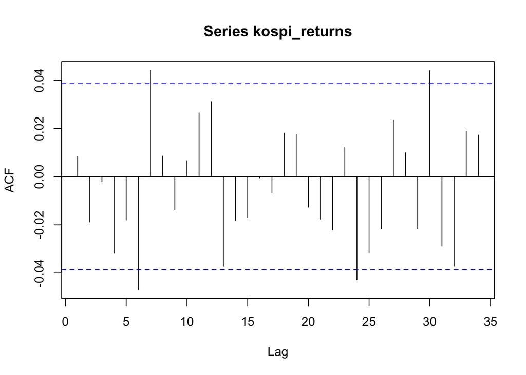

```r
acf(kospi_returns)
```

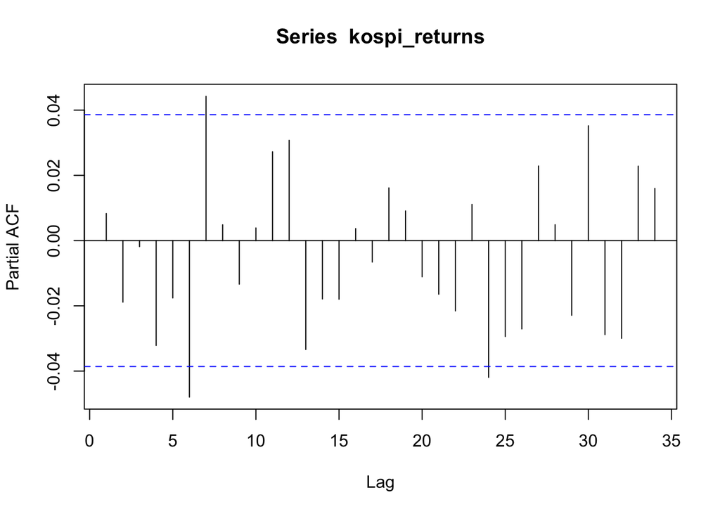

```r
pacf(kospi_returns)
```

There doesn’t appear to be any obvious pattern in the ACF or PACF plots. Moreover, the majority of the correlations are not significant. We can conclude that our returns are indeed somewhat uncorrelated over time! Now, let’s see if we can detect some ARCH effects…

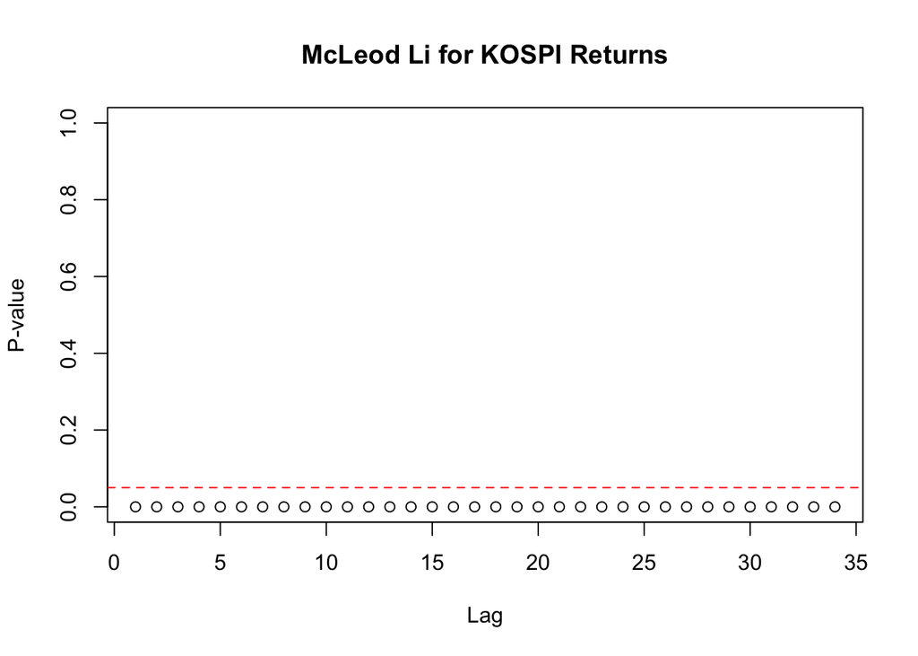

```r
McLeod.Li.test(y=kospi_returns, main = "McLeod Li for KOSPI Returns")
```

All of our p-values are significant! There are definitely ARCH effect present. Let’s move on to some modeling!

# Part 2: Modeling

## Model 1 - GARCH

First, let’s try fitting a GARCH model. Below we plot the ACF, PACF of the squared returns and the EACF to help us decide the order of our GARCH model…

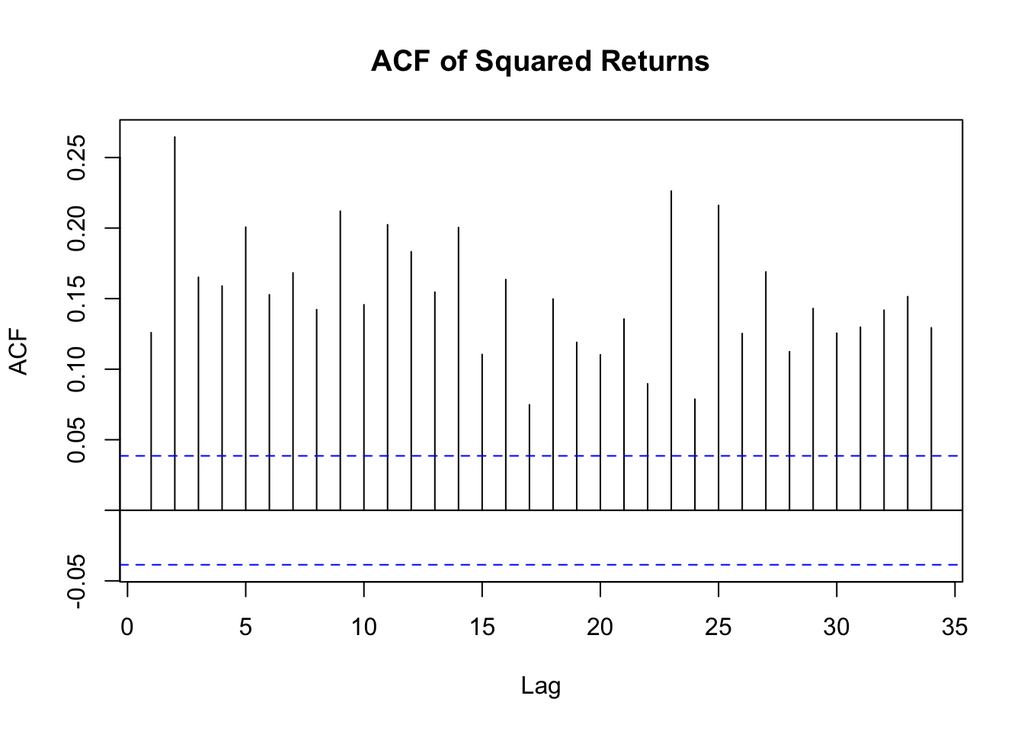

```r
acf(kospi_returns^2, main = "ACF of Squared Returns")
```

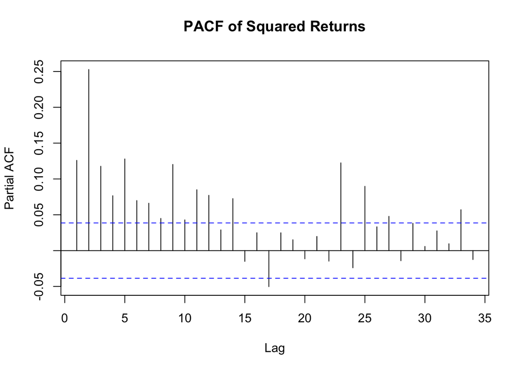

```r
pacf(kospi_returns^2, main = "PACF of Squared Returns")
```

```r
eacf(kospi_returns)
```

```
## AR/MA
##   0 1 2 3 4 5 6 7 8 9 10 11 12 13
## 0 o o o o o x x o o o o  o  o  o
## 1 x o o o o o x o o o o  o  x  o
## 2 x x o o o x o o o o o  o  x  o
## 3 x x x o o x x o o o o  o  x  o
## 4 x x x x o x o o o o o  o  x  o
## 5 x x x x x o o o o o o  o  o  o
## 6 x x x x x x o o o o o  o  o  o
## 7 x x x x o x x o o o o  o  o  o
```

Based on the EACF plot, let’s try a GARCH(1,1) model…

```r
model1<- garch(x=kospi_returns, order = c(1,1))
```

```
##
##  ***** ESTIMATION WITH ANALYTICAL GRADIENT *****
##
##
##      I     INITIAL X(I)        D(I)
##
##      1     9.096673e-05     1.000e+00
##      2     5.000000e-02     1.000e+00
##      3     5.000000e-02     1.000e+00
##
##     IT   NF      F         RELDF    PRELDF    RELDX   STPPAR   D*STEP   NPRELDF
##      0    1 -1.060e+04
##      1    8 -1.060e+04  6.47e-05  1.17e-04  2.9e-05  1.5e+11  2.9e-06  8.91e+06
##      2    9 -1.060e+04  5.24e-07  5.59e-07  2.8e-05  2.0e+00  2.9e-06  6.97e+00
##      3   17 -1.061e+04  1.27e-03  1.70e-03  3.1e-01  2.0e+00  4.7e-02  6.96e+00
##      4   20 -1.064e+04  2.96e-03  2.99e-03  6.0e-01  2.0e+00  1.9e-01  1.67e+00
##      5   22 -1.071e+04  5.75e-03  5.99e-03  4.3e-01  1.8e+00  3.8e-01  2.75e-01
##      6   30 -1.071e+04  1.99e-04  4.64e-04  1.6e-06  9.6e+00  2.0e-06  1.47e-02
##      7   31 -1.071e+04  4.11e-06  3.28e-06  1.6e-06  2.0e+00  2.0e-06  6.60e-03
##      8   40 -1.071e+04  3.11e-04  3.52e-04  2.6e-02  1.5e+00  3.3e-02  6.80e-03
##      9   42 -1.073e+04  1.25e-03  1.21e-03  9.1e-02  3.3e-01  1.3e-01  1.30e-03
##     10   44 -1.076e+04  3.02e-03  1.73e-03  6.7e-02  0.0e+00  1.4e-01  1.73e-03
##     11   46 -1.077e+04  1.48e-03  1.56e-03  2.4e-02  1.8e+00  5.5e-02  2.53e-02
##     12   56 -1.077e+04  2.24e-05  5.41e-05  8.3e-08  5.2e+00  1.5e-07  1.32e-02
##     13   57 -1.077e+04  1.44e-06  1.27e-06  7.1e-08  2.0e+00  1.5e-07  1.02e-02
##     14   67 -1.078e+04  4.49e-04  1.30e-03  1.9e-02  1.7e+00  4.0e-02  1.02e-02
##     15   68 -1.078e+04  1.07e-04  3.56e-04  7.7e-03  0.0e+00  1.6e-02  3.56e-04
##     16   69 -1.078e+04  8.26e-05  7.60e-05  6.9e-03  3.4e-01  1.6e-02  7.98e-05
##     17   71 -1.078e+04  3.13e-05  4.66e-05  1.6e-03  8.4e-01  3.1e-03  7.81e-05
##     18   72 -1.078e+04  1.34e-07  5.14e-07  1.4e-04  0.0e+00  3.0e-04  5.14e-07
##     19   73 -1.078e+04  1.18e-07  8.59e-08  3.5e-05  0.0e+00  7.0e-05  8.59e-08
##     20   74 -1.078e+04  6.23e-10  1.65e-09  1.2e-05  0.0e+00  2.5e-05  1.65e-09
##     21   75 -1.078e+04  1.32e-09  8.86e-11  6.2e-06  0.0e+00  1.6e-05  8.86e-11
##     22   76 -1.078e+04 -4.02e-10  2.27e-12  1.3e-06  0.0e+00  3.0e-06  2.27e-12
##
##  ***** RELATIVE FUNCTION CONVERGENCE *****
##
##  FUNCTION    -1.078101e+04   RELDX        1.347e-06
##  FUNC. EVALS      76         GRAD. EVALS      22
##  PRELDF       2.273e-12      NPRELDF      2.273e-12
##
##      I      FINAL X(I)        D(I)          G(I)
##
##      1    1.450497e-06     1.000e+00     4.444e+02
##      2    4.535456e-02     1.000e+00     2.290e-02
##      3    9.385956e-01     1.000e+00     4.772e-02
```

```r
summary(model1)
```

```
##
## Call:
## garch(x = kospi_returns, order = c(1, 1))
##
## Model:
## GARCH(1,1)
##
## Residuals:
##      Min       1Q   Median       3Q      Max
## -5.59611 -0.54419  0.03274  0.59084  3.44550
##
## Coefficient(s):
##     Estimate  Std. Error  t value Pr(>|t|)
## a0 1.450e-06   3.188e-07    4.550 5.35e-06 ***
## a1 4.535e-02   5.776e-03    7.852 4.00e-15 ***
## b1 9.386e-01   7.781e-03  120.628  < 2e-16 ***
## ---
## Signif. codes:  0 '***' 0.001 '**' 0.01 '*' 0.05 '.' 0.1 ' ' 1
##
## Diagnostic Tests:
##  Jarque Bera Test
##
## data:  Residuals
## X-squared = 268.41, df = 2, p-value < 2.2e-16
##
##
##  Box-Ljung test
##
## data:  Squared.Residuals
## X-squared = 0.9826, df = 1, p-value = 0.3216
```

The estimated model is $x_t = \sigma_t\epsilon_t$ where $\sigma_t^2 = 1.450e^{-6} + 4.535e^{-2} X_{t-1}^2+9.386e^{-1}\sigma_{t-1}^2$. As we can see from the summary output above, all of our model coefficients are significant at the .05 significance level (good). Moreover, our model passes the Box-Ljung test which shows that our squared residuals are not significantly correlated (good). However, our model fails that Jarque Bera test meaning our residuals are not normally distributed (bad). We plot the QQPLot of the residuals below…

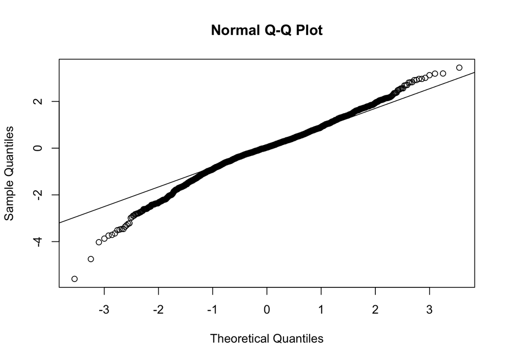

```r
qqnorm(model1$residuals)
qqline(model1$residuals)
```

As we can see from the above QQPlot, are residuals are definitely not normal. This means we should try another model that can better fit the data and try to capture some of the non-normality in the residuals. Before we move on, lets plot the estimated conditional variance (i.e. volatility) estimated by the model and compare to the VKOSPI values.

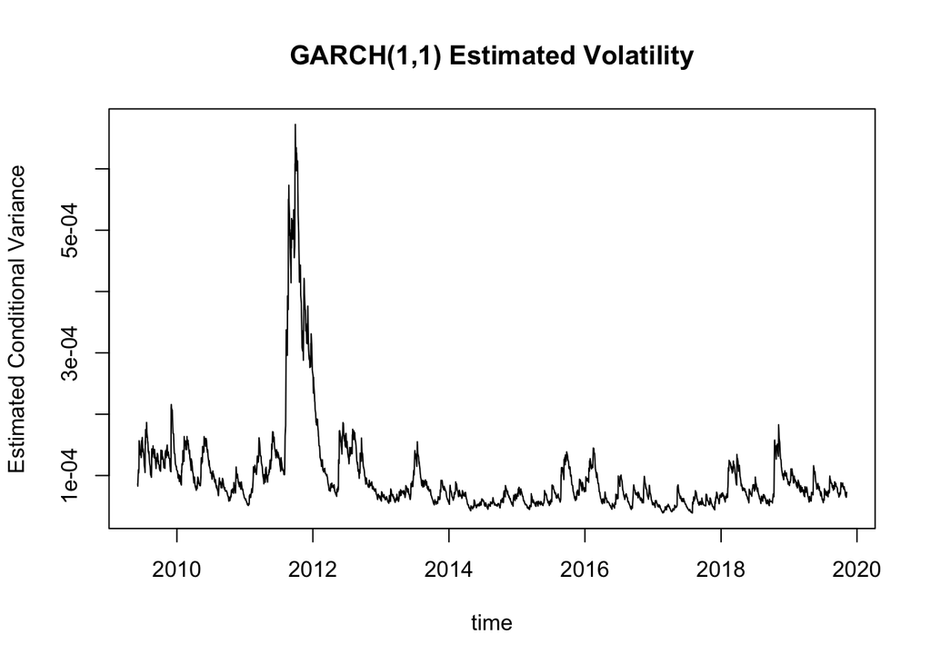

```r
plot(time[2:length(time)], (model1$fitted.values[,1])^2, type = 'l',  xlab = "time", ylab = 'Estimated Conditional Variance', main = "GARCH(1,1) Estimated Volatility" ) #estimated volatility
```

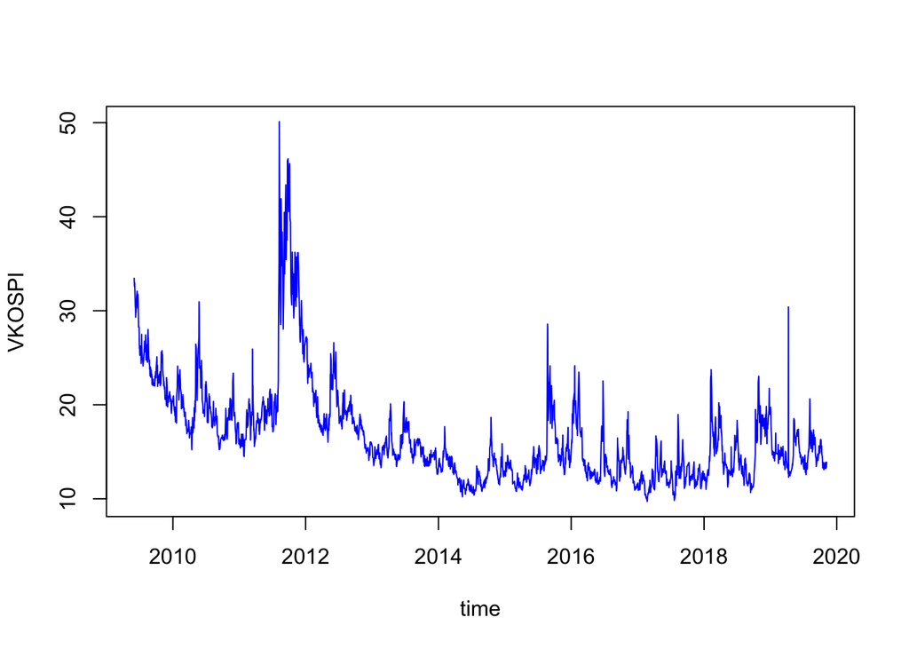

```r
plot(time, vkospi, type = 'l', col = 'blue', ylab = 'VKOSPI')
```

We can see that there is some similarity in trend between the volatility estimated by our model and the VKOSPI. For example, there is a very noticeable peak near 2012 in the estimated volatility as there is in the VKOSPI series. Below we plot the CCF plot of the estimated values from our model against the VKOSPI series. As we can see from the CCF plot, the estimated volatilities from our model are highly correlated with the VKOSPI series. Moreover, the peak of the plot occurs near (but not exactly at) lag 0 showing that our model does pretty well in estimating a similar volatility trend as found in the VKOSPI series.

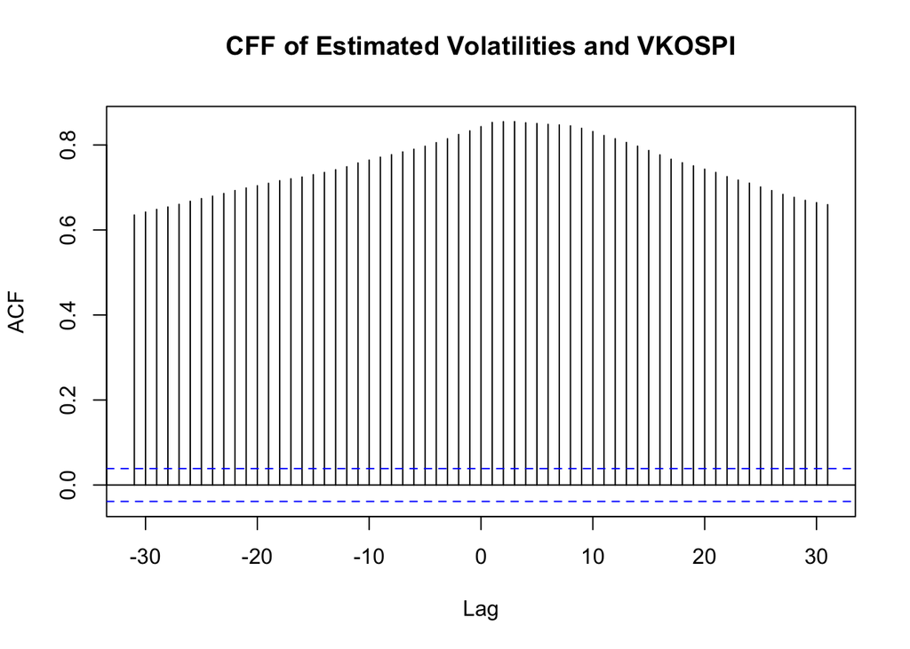

```r
estimated_values = (model1$fitted.values[,1])^2
ccf(estimated_values[2:length(estimated_values)], vkospi[2:length(estimated_values)], main = "CFF of Estimated Volatilities and VKOSPI")
```

## Model 2 - EGARCH

EGARCH (Exponential Generalized Autoregressive Conditional Heteroskedasticity) is an extension of the GARCH (Generalized Autoregressive Conditional Heteroskedasticity) model that allows for asymmetric volatility. The EGARCH model is specified in terms of the logarithm of the conditional variance, which allows for the conditional variance to be negative. The EGARCH model also includes an exponential term, which helps to capture the long-term effects of volatility shocks. The main difference between the EGARCH and GARCH models is that the EGARCH model allows for asymmetric volatility effects, while the GARCH model assumes that volatility responds symmetrically to positive and negative shocks.

Like we did in GARCH, we fitted an EGARCH(1, 1) model on the returns. The distribution of the standardized residuals is assumed to be normal.

```r
#Specify EGARCH models
egarch.spec <-  ugarchspec(variance.model=list(model="eGARCH",garchOrder=c(1,1)),
                            mean.model=list(armaOrder=c(0,0)))
#fit EGARCH model
egarch_model11 <- ugarchfit(spec=egarch.spec, data = kospi_returns)
```

```r
# check the summary of egarch model
egarch_model11
```

```
##
## *---------------------------------*
## *          GARCH Model Fit        *
## *---------------------------------*
##
## Conditional Variance Dynamics
## -----------------------------------
## GARCH Model  : eGARCH(1,1)
## Mean Model   : ARFIMA(0,0,0)
## Distribution : norm
##
## Optimal Parameters
## ------------------------------------
##         Estimate  Std. Error     t value Pr(>|t|)
## mu     -0.000057    0.000168    -0.34043  0.73353
## omega  -0.169877    0.001915   -88.68948  0.00000
## alpha1 -0.073027    0.006130   -11.91287  0.00000
## beta1   0.981521    0.000015 67328.93927  0.00000
## gamma1  0.079550    0.007583    10.49125  0.00000
##
## Robust Standard Errors:
##         Estimate  Std. Error     t value Pr(>|t|)
## mu     -0.000057    0.000174    -0.32719  0.74353
## omega  -0.169877    0.002519   -67.42751  0.00000
## alpha1 -0.073027    0.008492    -8.59917  0.00000
## beta1   0.981521    0.000017 56633.97744  0.00000
## gamma1  0.079550    0.010245     7.76473  0.00000
##
## LogLikelihood : 8446.648
##
## Information Criteria
## ------------------------------------
##
## Akaike       -6.5465
## Bayes        -6.5351
## Shibata      -6.5465
## Hannan-Quinn -6.5423
##
## Weighted Ljung-Box Test on Standardized Residuals
## ------------------------------------
```

[output cut: 40 more lines]

```
## Negative Sign Bias 0.07635 0.93915
## Positive Sign Bias 2.14988 0.03166  **
## Joint Effect       9.79978 0.02035  **
##
##
## Adjusted Pearson Goodness-of-Fit Test:
## ------------------------------------
##   group statistic p-value(g-1)
## 1    20     106.9    3.017e-14
## 2    30     128.8    1.567e-14
## 3    40     133.8    2.585e-12
## 4    50     154.8    6.604e-13
##
##
## Elapsed time : 0.139472
```

Interpreting output: The estimated model is $\epsilon_t=\sigma_tz_t$ where $z_t$ is standard Gaussian and $ln(\sigma_t^2) =-0.073 \frac{|-0.1699|+0.0796*(-0.1699)}{\sigma_{t-1}} + 0.98ln(\sigma_{t-1}^2)$. The alpha1 coefficient is statistically significant as its p-value is 0.00000, telling that past volatility has an impact on current volatility. Also, Weighted Ljung-Box Test on Standardized Residuals says no serial correlation meaning that the test found no significant evidence of autocorrelation in the standardized residuals up to a certain lag. In addition, the Adjusted Pearson Goodness-of-Fit Test returns a low number, meaning that the model does not fit the data well. Therefore, we will attempt on a new EGARCH model by alternating to t-distribution.

```r
#EGARCH with t distribution
#Specify EGARCH models:
spec = ugarchspec(variance.model=list(model="eGARCH",garchOrder=c(1,1)), mean.model=list(armaOrder=c(0,0)),distribution.model="std")
#fit EGARCH model
egarch_model11.t=ugarchfit(data=kospi_returns, spec=spec)
##summary of EGARCH fit
egarch_model11.t
```

```
##
## *---------------------------------*
## *          GARCH Model Fit        *
## *---------------------------------*
##
## Conditional Variance Dynamics
## -----------------------------------
## GARCH Model  : eGARCH(1,1)
## Mean Model   : ARFIMA(0,0,0)
## Distribution : std
##
## Optimal Parameters
## ------------------------------------
##         Estimate  Std. Error   t value Pr(>|t|)
## mu      0.000202    0.000153    1.3148  0.18858
## omega  -0.171596    0.001955  -87.7949  0.00000
## alpha1 -0.087008    0.011683   -7.4472  0.00000
## beta1   0.981879    0.000172 5719.7097  0.00000
## gamma1  0.088698    0.003931   22.5621  0.00000
## shape   6.196543    0.739137    8.3835  0.00000
##
## Robust Standard Errors:
##         Estimate  Std. Error   t value Pr(>|t|)
## mu      0.000202    0.000156    1.2896  0.19718
## omega  -0.171596    0.002920  -58.7728  0.00000
## alpha1 -0.087008    0.012774   -6.8115  0.00000
## beta1   0.981879    0.000169 5826.0777  0.00000
## gamma1  0.088698    0.006198   14.3111  0.00000
## shape   6.196543    0.686608    9.0249  0.00000
##
## LogLikelihood : 8494.37
##
## Information Criteria
## ------------------------------------
##
## Akaike       -6.5827
## Bayes        -6.5691
## Shibata      -6.5827
## Hannan-Quinn -6.5777
##
```

[output cut: 43 more lines]

```
## Negative Sign Bias  0.3888 0.69748
## Positive Sign Bias  2.1794 0.02939  **
## Joint Effect        8.2387 0.04133  **
##
##
## Adjusted Pearson Goodness-of-Fit Test:
## ------------------------------------
##   group statistic p-value(g-1)
## 1    20     50.97    9.412e-05
## 2    30     66.08    1.021e-04
## 3    40     89.00    8.896e-06
## 4    50     98.57    3.487e-05
##
##
## Elapsed time : 0.286773
```

For t distribution model, the estimated model is $\epsilon_t=\sigma_tz_t$ where $ln(\sigma_t^2) = 0.0002 + -0.087 \frac{|-0.172|+0.088*(-0.172)}{\sigma_{t-1}} + 0.98ln(\sigma_{t-1}^2)$. The alpha1 coefficient is also statistically significant as its p-value is 0.00000, telling that past volatility has an impact on current volatility. Weighted Ljung-Box Test on Standardized Residuals also says no serial correlation meaning that the test found no significant evidence of autocorrelation in the standardized residuals up to a certain lag. In addition, even though the Adjusted Pearson Goodness-of-Fit Test is higher than that of the normal distribution, the number is still low so we shoudl conclude that the model does not fit the data well.

For both of the EGARCH models, we may notice that leverage effect presents because alpha1 is smaller than 0.

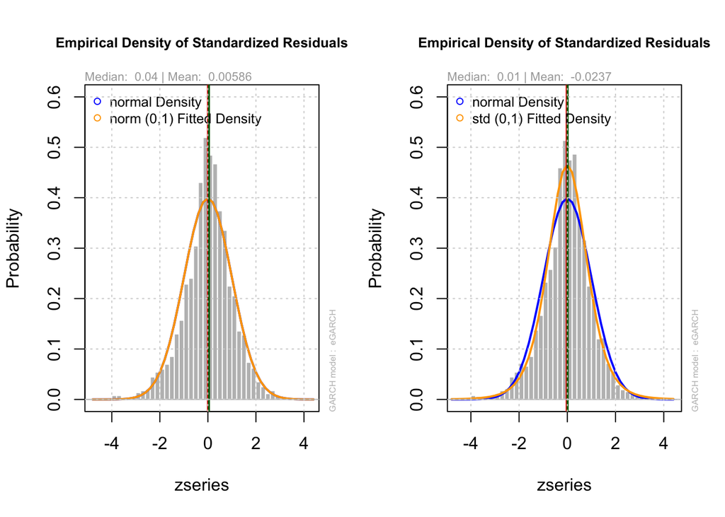

```r
##QQ-plot for fitted GARCH Model with t distribution
options(repr.plot.width=20, repr.plot.height=8)
par(mfrow=c(1,2))
plot(egarch_model11, which=8)
plot(egarch_model11.t, which=8)
```

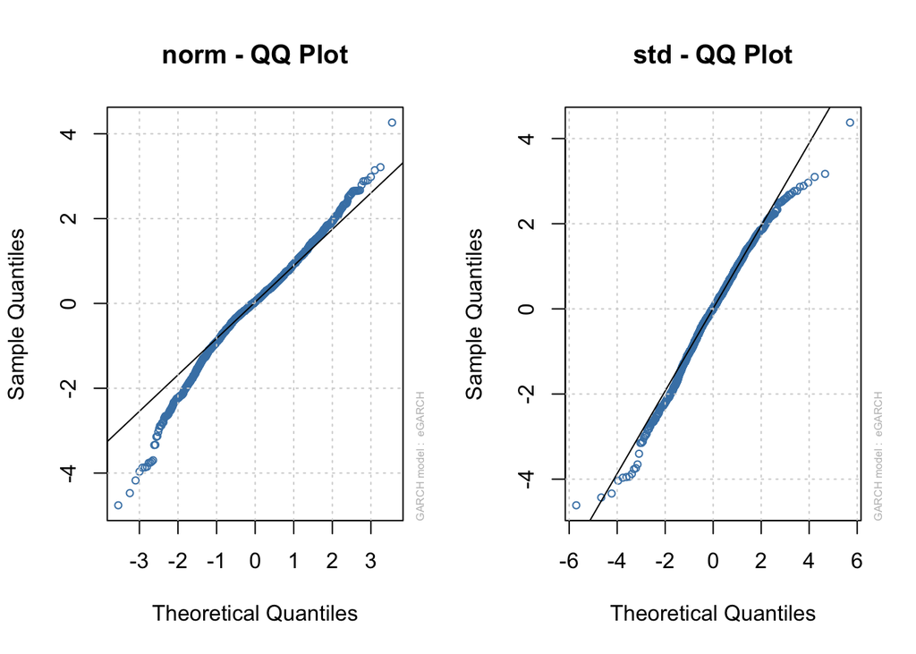

```r
plot(egarch_model11, which=9)
plot(egarch_model11.t, which=9)
```

Comparing between two different distributions of EGARCH, the EGARCH-t distribution QQ-plot seems to be more straight. However, we will try to estimate with IGARCH to check if it returns better results.

## Model 3 - IGARCH

The IGARCH (Integrated Generalized Autoregressive Conditional Heteroskedasticity) model is a special case of the GARCH model, where the sum of the AR and MA coefficients is constrained to equal one (thereby exhibiting persistence). This restriction implies that the shocks to the volatility have a permanent effect, and that the volatility process is non-stationary.

As as result, IGARCH is specifically designed to capture non-stationary processes, with the persistence of the volatility shocks lasting indefinitely; therefore, it might provide better forecasts for non-stationary volatilities.

Another advantage to using IGARCH is that they have fewer parameters due to the constraint, which can lead to simpler models and potentially more stable parameter estimates.

Now, we fit an IGARCH(1, 1) model on the returns. The distribution of the standardized residuals is assumed to be normal.

```r
# model specifications
spec <- ugarchspec(
  variance.model = list(model = "iGARCH", garchOrder = c(1, 1)),
  mean.model = list(armaOrder = c(0, 0), include.mean = TRUE),
  distribution.model = "norm"
)

# fit model
igarch_11 <- ugarchfit(spec, data = kospi_returns)
igarch_11
```

```
##
## *---------------------------------*
## *          GARCH Model Fit        *
## *---------------------------------*
##
## Conditional Variance Dynamics
## -----------------------------------
## GARCH Model  : iGARCH(1,1)
## Mean Model   : ARFIMA(0,0,0)
## Distribution : norm
##
## Optimal Parameters
## ------------------------------------
##         Estimate  Std. Error  t value Pr(>|t|)
## mu      0.000134    0.000172  0.77865  0.43618
## omega   0.000000    0.000000  1.00435  0.31521
## alpha1  0.046418    0.004867  9.53692  0.00000
## beta1   0.953582          NA       NA       NA
##
## Robust Standard Errors:
##         Estimate  Std. Error  t value Pr(>|t|)
## mu      0.000134    0.000175  0.76221  0.44593
## omega   0.000000    0.000001  0.24009  0.81026
## alpha1  0.046418    0.033181  1.39892  0.16184
## beta1   0.953582          NA       NA       NA
##
## LogLikelihood : 8408.048
##
## Information Criteria
## ------------------------------------
##
## Akaike       -6.5181
## Bayes        -6.5113
## Shibata      -6.5181
## Hannan-Quinn -6.5156
##
## Weighted Ljung-Box Test on Standardized Residuals
## ------------------------------------
##                         statistic p-value
## Lag[1]                     0.1747  0.6760
```

[output cut: 36 more lines]

```
## Negative Sign Bias  0.6628 5.075e-01
## Positive Sign Bias  3.0777 2.108e-03 ***
## Joint Effect       22.3441 5.531e-05 ***
##
##
## Adjusted Pearson Goodness-of-Fit Test:
## ------------------------------------
##   group statistic p-value(g-1)
## 1    20     123.8    2.117e-17
## 2    30     133.6    2.316e-15
## 3    40     159.4    1.726e-16
## 4    50     197.0    1.223e-19
##
##
## Elapsed time : 0.063555
```

Interpreting output:

Notably, the alpha1 coefficient is statistically significant with a p-value of 0.00000, indicating that past volatility has a significant impact on current volatility.

The Ljung-Box test results for the standardized residuals and squared residuals indicate no significant serial correlation, suggesting that the model has adequately captured the autocorrelation structure in the returns and volatility.

The adjusted Pearson goodness-of-fit test assesses the fit of the model’s assumed distribution to the data. The p-values are very small, indicating that the normal distribution may not be an appropriate assumption for the standardized residuals. This might suggest considering alternative distribution assumptions, such as the Student’s t-distribution or the Generalized Error Distribution.

Next, we attempt fitting the same model but with a t-distribution assumption:

```r
# model specifications
spec <- ugarchspec(
  variance.model = list(model = "iGARCH", garchOrder = c(1, 1)),
  mean.model = list(armaOrder = c(0, 0), include.mean = TRUE),
  distribution.model = "std"
)

# fit model
igarch_11.t <- ugarchfit(spec, data = kospi_returns)
igarch_11.t
```

```
##
## *---------------------------------*
## *          GARCH Model Fit        *
## *---------------------------------*
##
## Conditional Variance Dynamics
## -----------------------------------
## GARCH Model  : iGARCH(1,1)
## Mean Model   : ARFIMA(0,0,0)
## Distribution : std
##
## Optimal Parameters
## ------------------------------------
##         Estimate  Std. Error  t value Pr(>|t|)
## mu      0.000351    0.000158   2.2168 0.026638
## omega   0.000000    0.000000   1.3228 0.185895
## alpha1  0.045723    0.003852  11.8711 0.000000
## beta1   0.954277          NA       NA       NA
## shape   5.248051    0.498325  10.5314 0.000000
##
## Robust Standard Errors:
##         Estimate  Std. Error  t value Pr(>|t|)
## mu      0.000351    0.000160  2.19257 0.028338
## omega   0.000000    0.000001  0.62337 0.533043
## alpha1  0.045723    0.017826  2.56503 0.010317
## beta1   0.954277          NA       NA       NA
## shape   5.248051    0.508598 10.31866 0.000000
##
## LogLikelihood : 8467.398
##
## Information Criteria
## ------------------------------------
##
## Akaike       -6.5633
## Bayes        -6.5542
## Shibata      -6.5633
## Hannan-Quinn -6.5600
##
## Weighted Ljung-Box Test on Standardized Residuals
## ------------------------------------
```

[output cut: 39 more lines]

```
## Negative Sign Bias  0.9091 3.634e-01
## Positive Sign Bias  3.0989 1.963e-03 ***
## Joint Effect       21.6741 7.625e-05 ***
##
##
## Adjusted Pearson Goodness-of-Fit Test:
## ------------------------------------
##   group statistic p-value(g-1)
## 1    20     40.30    0.0029862
## 2    30     56.45    0.0016706
## 3    40     75.07    0.0004568
## 4    50     93.84    0.0001218
##
##
## Elapsed time : 0.1457849
```

Interpreting output:

We observe that parameters mu, alpha1, and shape are all statistically significant, suggesting that the t-distribution assumption improves the model fit.

The Ljung-Box test results for the standardized residuals and squared residuals indicate no significant serial correlation, suggesting that the model has adequately captured the autocorrelation structure in the returns and volatility.

Finally, to visualize the comparison, we plot their QQ-plots:

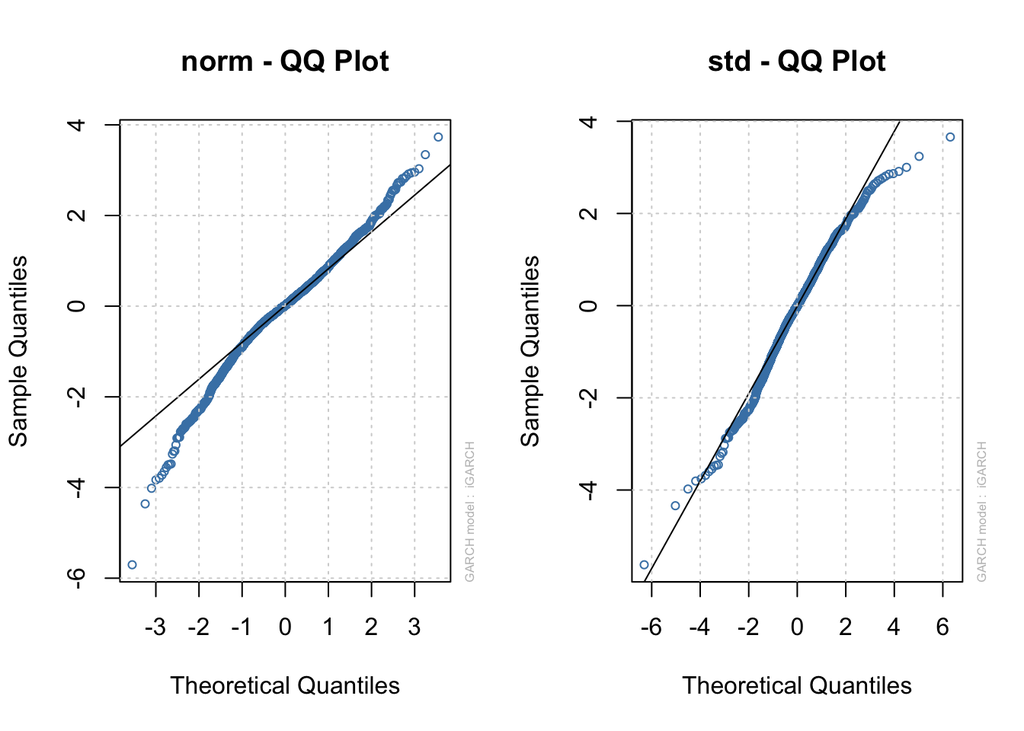

```r
par(mfrow=c(1,2))
plot(igarch_11, which=9)
plot(igarch_11.t, which=9)
```

# Part 3: Model Comparison

Previously, we fit a few models on predicting volatility. We have GARCH and its variants EGARCH and IGARCH. We are now interested in determining which is the best. To accomplish this, we can use metrics such as the Akaike Information Criterion (AIC) and the Bayesian Information Criterion (BIC), as well as the log-likelihood of each model. The model with the lowest AIC and BIC values and the highest log-likelihood is generally considered the best fitting model.

```r
# a helper function
extract_criteria <- function(fit) {
  aic <- tryCatch({
    infocriteria(fit)[1]
  }, error = function(cond) {
    log_likelihood <- as.numeric(logLik(fit))
    n_params <- length(coef(fit))
    -2 * log_likelihood + 2 * n_params
  })

  bic <- tryCatch({
    infocriteria(fit)[2]
  }, error = function(cond) {
    log_likelihood <- as.numeric(logLik(fit))
    n_params <- length(coef(fit))
    -2 * log_likelihood + n_params * log(length(kospi_returns))
  })

  loglik <- tryCatch({
    likelihood(fit)
  }, error = function(cond) {
    as.numeric(logLik(fit))
  })
  return(c(aic, bic, loglik))
}

# get criteria from each model
criteria <- lapply(list(model1, egarch_model11.t, igarch_11.t), extract_criteria)

# store results
model_comparison <- data.frame(Model = c("GARCH", "EGARCH", "IGARCH"),
                               AIC = sapply(criteria, "[", 1),
                               BIC = sapply(criteria, "[", 2),
                               LogLik = sapply(criteria, "[", 3))
model_comparison
```

```
##    Model           AIC           BIC   LogLik
## 1  GARCH -16817.982298 -16800.416827 8411.991
## 2 EGARCH     -6.582683     -6.569062 8494.370
## 3 IGARCH     -6.563318     -6.554236 8467.398
```

```r
# determine the best model
best_model_aic <- model_comparison[which.min(model_comparison$AIC), "Model"]
best_model_bic <- model_comparison[which.min(model_comparison$BIC), "Model"]
best_model_loglik <- model_comparison[which.max(model_comparison$LogLik), "Model"]

cat("Best model based on AIC:", best_model_aic, "\n")
```

```
## Best model based on AIC: GARCH
```

```r
cat("Best model based on BIC:", best_model_bic, "\n")
```

```
## Best model based on BIC: GARCH
```

```r
cat("Best model based on log-likelihood:", best_model_loglik, "\n")
```

```
## Best model based on log-likelihood: EGARCH
```

Observations: